# Kaldheim Archetype Clustering

## Modeling deck archetypes as biological data

Like many others, I was listening to the [Limited Resources](http://lrcast.com/) episode talking about [17lands](https://www.17lands.com/), when I heard Sierkovitz mention that they have publicly available datasets to analyze. I immediately got excited thinking about what analyses I may be able to do with the public data, and as a bioinformatician my first thought was whether or not I could use any of the computational techniques we apply to biological data to MTG data. As odd as that may sound, I quickly realized that there are a lot of similarities between the way we describe draft decks and the way we describe single cell RNA sequencing data!

For a biological organism, the first thing to consider is the genome which (if vastly oversimplified) describes the set of all possible genes that can be expressed in a cell. Likewise, in a draft environment you have the set you are drafting which describes all possible cards that can be opened in a draft booster. So in this analogy, the set is the genome of the draft environment, and the cards are the genes. This describes what is possible, but the actual functional unit of an organism is its cells. In any given cell, it technically can express any gene in the genome, but in reality only certain genes will be expressed. In a pancreas cell for example, you will find the gene for insulin being expressed, but this gene will never be active in a blood cell. Likewise, in a draft environment, the functional unit of the draft is the deck. Each deck could technically contain any card in the set, but in practice it contains a specific subset. So at this point in the analogy we have a draft environment (genome) that describes all of the cards (genes) that can ultimately be drafted to build a deck (cells).

So now that we see that the draft data can be structured in a way that reflects biological data, we can apply computational techniques that have been developed for this biological data to the draft data. In particular, I thought it would be interesting to do de novo clustering of draft decks using the same techniques we use for single cell RNA sequencing data. For a single cell RNA experiment, we take thousands of individual cells and we look at which genes are expressed. Even if we don’t know what cell types are in our experiment, or what genes they might express, we know that similar cells should express similar genes, and so we can cluster the cells based on the genes they express. After this is done we can dig into the clusters and see what actual genes are driving clustering, and therefore form the backbone of the cluster. In a similar way, we can take draft deck data and cluster the decks based on the cards that are present. After clustering, we can dig into the clusters and see which cards drive each cluster. The final interpretation of this would be that each cluster represents a draft archetype, and the size of the cluster represents how often that archetype ends up being drafted.

The first thing to do is read in our data and get it in a form that it can be passed to existing single cell RNA seq analysis packages.

```r
library(tidyverse)
library(scRNAseq)
library(scuttle)
library(scran)
library(scater)

kaldheim_data <- read_csv("game-data.KHM.PremierDraft.csv")

#Select only deck columns
kaldheim_decks <- kaldheim_data %>%
  dplyr::select(starts_with("deck"))

#Normalize card names
names(kaldheim_decks) <- names(kaldheim_decks) %>%
  gsub("deck_" , "", .) %>%
  gsub("[ -]", "_", .) %>%
  gsub("[',]", "", .) %>%
  tolower()

#Remove cards that cannot actually be in the deck
#This includes the back face of modal cards, and non-booster cards
modal_cards <- c("tibalt_cosmic_impostor", "tidechannel_pathway", "searstep_pathway", "slitherbore_pathway", "mistgate_pathway", "sword_of_the_realms", "valkmira_protectors_shield", "hakka_whispering_raven", "the_omenkeel", "throne_of_death", "tergrids_lantern", "harnfel_horn_of_bounty", "toralfs_hammer", "the_prismatic_bridge", "kaldring_the_rimestaff", "the_ringhart_crest")

non_draft_cards <- c("absorb_identity", "armed_and_armored", "bearded_axe", "canopy_tactician", "cleaving_reaper", "elderfang_ritualist", "elven_ambush", "fire_giants_fury", "giants_grasp", "gilded_assault_cart", "gladewalker_ritualist", "rampage_of_the_valkyries", "renegade_reaper", "starnheim_aspirant", "surtland_elementalist", "surtland_flinger", "thornmantle_striker", "valkyrie_harbinger", "warchanter_skald", "youthful_valkyrie")

kaldheim_decks <- kaldheim_decks %>%
  select(-all_of(modal_cards), -all_of(non_draft_cards))

#Remove duplicate decks
#Each row corresponds to a single game played, so decks show up multiple times
kaldheim_decks <- unique(kaldheim_decks)

#Remove NA rows
kaldheim_decks <- kaldheim_decks %>%
  filter(!is.na(alpine_meadow))
kaldheim_unique <- kaldheim_decks

#Take smaller random sample to improve runtime
set.seed(12345)
kaldheim_decks <- kaldheim_decks %>%
  sample_n(3000, replace = FALSE)
kaldheim_sample <- kaldheim_decks

#Remove basic lands as they aren't actually drafted
basic_lands <- c("island", "forest", "mountain", "plains", "swamp")

kaldheim_decks <- kaldheim_decks %>%
  select(-all_of(basic_lands))

#Single cell data has genes as rows, and cells as columns
#Transpose data to fit this data scheme
cards <- names(kaldheim_decks)
kaldheim_decks <- t(kaldheim_decks)

#Finally, put data into a SingleCellExperiment object for use with scRNAseq packages
kaldheim_sce <- SingleCellExperiment(list(counts = kaldheim_decks))
```

## Clustering the RNA seq data

Now we can actually cluster the data. I am using the [tutorial](https://bioconductor.org/packages/devel/bioc/vignettes/scran/inst/doc/scran.html) for the scran Bioconductor package as the basis for the analysis. We would normally start with quality control to remove technical artifacts from the data, but since we know exactly which cards were drafted there shouldn’t be any technical artifacts to remove. This means we can jump right into clustering! This starts using principal components analysis to reduce the dimensionality of our data. Since this is de novo clustering and we don’t want to make assumptions about how many archetypes we expect to identify, we will use the getClusteredPCs function to optimize the number of clusters that maximizes finding distinct clusters without overclustering.

```r
#Run PCA
kaldheim_sce <- logNormCounts(kaldheim_sce)
kaldheim_sce <- runPCA(kaldheim_sce)

#Choose number of PCs to retain based on number of clusters
output <- getClusteredPCs(reducedDim(kaldheim_sce))
pc_n <- metadata(output)$chosen
reducedDim(kaldheim_sce, "PCAsub") <- reducedDim(kaldheim_sce, "PCA")[,1:pc_n,drop=FALSE]
```

Now that we have identified the number of clusters we expect, we can create a visualization by constructing a shared nearest-neighbor graph plotted on t-SNE coordinates. This is a visualization technique that lets you plot high-dimensional data on a 2-dimensional plane.

```r
#Build graph for tSNE plot
g <- buildSNNGraph(kaldheim_sce, use.dimred="PCAsub")
cluster <- igraph::cluster_walktrap(g)$membership

#Build tSNE plot
colLabels(kaldheim_sce) <- factor(cluster)
table(colLabels(kaldheim_sce))
```

```
##
##   1   2   3   4   5   6   7   8   9  10  11  12
## 211 266 319 379 143 244 421 173 334 135 236 139
```

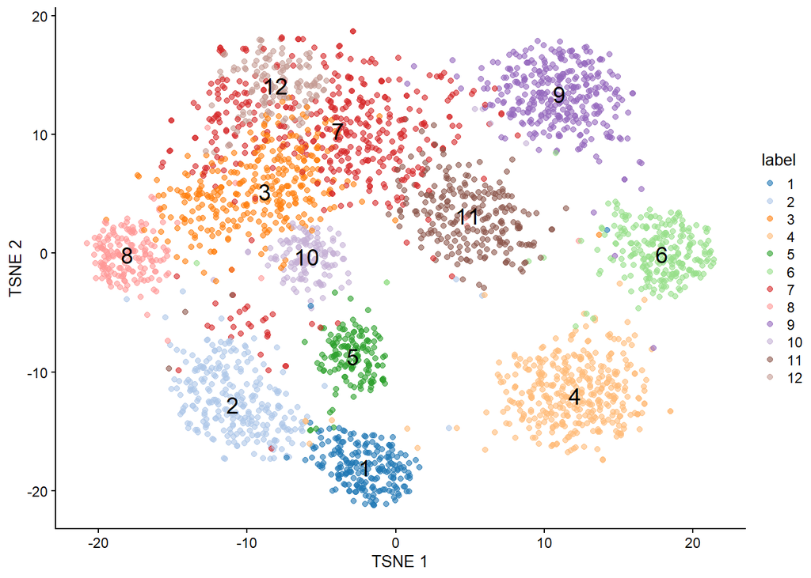

```r
kaldheim_sce <- runTSNE(kaldheim_sce)
plotTSNE(kaldheim_sce, colour_by="label", text_by="label")
```

We can see that we get quite a few nice clusters! These should in theory correspond to distinct draft archetypes. We can see what cards are most prevalent in each cluster to help us identify what archetype each cluster might represent. We can start by diving right into the muddled clusters at the top left.

```r
#Get top 20 cards from cluster 3
colSums(kaldheim_sample[which(cluster == 3), ]) %>% sort(decreasing = TRUE) %>% head(20)
```

```
##                     forest                      swamp
##                       1258                        849
##                     island         snow_covered_swamp
##                        552                        336
## priest_of_the_haunted_edge        snow_covered_forest
##                        323                        277
##              icehide_troll          shimmerdrift_vale
##                        274                        250
##        snow_covered_island         sculptor_of_winter
##                        240                        226
##           sarulfs_packmate           glittering_frost
##                        179                        178
##               berg_strider           feed_the_serpent
##                        169                        159
##              masked_vandal      behold_the_multiverse
##                        149                        145
##             horizon_seeker                   mountain
##                        139                        133
##                 ice_tunnel             woodland_chasm
##                        132                        131
```

Cluster 3 has forest, swamp, island, and mountain all in the top 20 cards, suggesting this is a multi-color deck. It also contains quite a few snow payoffs. We can infer that this is likely 5-color snow, and this explains why this cluster is so intermingled with other clusters - it can contain many cards often seen in other archetypes.

```r
#Get top 20 cards from cluster 7
colSums(kaldheim_sample[which(cluster == 7), ]) %>% sort(decreasing = TRUE) %>% head(20)
```

```
##                 forest                 island               mountain
##                   1939                   1104                    548
##    snow_covered_forest  snow_covered_mountain    snow_covered_island
##                    371                    325                    321
##      shimmerdrift_vale          icehide_troll     sculptor_of_winter
##                    320                    313                    294
##       glittering_frost       sarulfs_packmate      ravenous_lindwurm
##                    292                    292                    265
##           berg_strider                  swamp          masked_vandal
##                    264                    255                    244
##  behold_the_multiverse         horizon_seeker             mistwalker
##                    234                    214                    211
##   struggle_for_skemfar path_to_the_world_tree
##                    202                    201
```

Cluster 7 is very similar, but with less black and more red. This is therefore another multi-color snow archetype but with slightly different color loads.

```r
#Get top 20 cards from cluster 12
colSums(kaldheim_sample[which(cluster == 12), ]) %>% sort(decreasing = TRUE) %>% head(20)
```

```
##                forest                island            mistwalker
##                   775                   706                   152
##   snow_covered_forest behold_the_multiverse   snow_covered_island
##                   143                   133                   129
##  struggle_for_skemfar     ravenous_lindwurm      sarulfs_packmate
##                   116                   110                    98
##          berg_strider    sculptor_of_winter          augury_raven
##                    97                    97                    96
##      glittering_frost         masked_vandal  moritte_of_the_frost
##                    94                    88                    82
##      bind_the_monster         icehide_troll        rimewood_falls
##                    81                    73                    71
##        horizon_seeker   littjara_kinseekers
##                    70                    68
```

Cluster 12 appears to be just blue/green snow, so while it shares many cards with clusters 3 and 7 it is distinct in its lack of red, black, and white cards.

```r
#Get top 20 cards from cluster 10
colSums(kaldheim_sample[which(cluster == 10), ]) %>% sort(decreasing = TRUE) %>% head(20)
```

```
##                      swamp                     island
##                        654                        627
##         snow_covered_swamp        snow_covered_island
##                        147                        139
##      behold_the_multiverse priest_of_the_haunted_edge
##                        115                        111
##                 mistwalker               berg_strider
##                        107                        106
##           feed_the_serpent               augury_raven
##                         88                         85
##          shimmerdrift_vale         elderfang_disciple
##                         81                         80
##       jarl_of_the_forsaken             komas_faithful
##                         78                         77
##          karfell_harbinger            port_of_karfell
##                         74                         65
##                grim_draugr        littjara_kinseekers
##                         63                         63
##                     plains       draugr_thought_thief
##                         62                         60
```

Cluster 10 appears to be blue/black snow, which again is consistent with its proximity to other snow clusters.

Now, what about the distinct outer clusters?

```r
#Get top 20 cards from cluster 1
colSums(kaldheim_sample[which(cluster == 1), ]) %>% sort(decreasing = TRUE) %>% head(20)
```

```
##                  plains                   swamp         doomskar_oracle
##                    1511                    1419                     193
##            story_seeker       stalwart_valkyrie        feed_the_serpent
##                     181                     174                     158
##           bound_in_gold        codespell_cleric       beskir_shieldmate
##                     151                     142                     138
##      elderfang_disciple            infernal_pet      battlefield_raptor
##                     133                     133                     130
##    firja_judge_of_valor    jarl_of_the_forsaken              weigh_down
##                     129                     125                     125
## great_hall_of_starnheim            iron_verdict    deathknell_berserker
##                     119                     118                      99
##       starnheim_courser        raise_the_draugr
##                      94                      89
```

```r
#Get top 20 cards from cluster 2
colSums(kaldheim_sample[which(cluster == 2), ]) %>% sort(decreasing = TRUE) %>% head(20)
```

```
##                   plains                   forest            bound_in_gold
##                     1804                     1649                      205
##        stalwart_valkyrie             story_seeker        beskir_shieldmate
##                      196                      196                      195
##     struggle_for_skemfar        starnheim_courser         sarulfs_packmate
##                      195                      182                      180
## maja_bretagard_protector            masked_vandal       battlefield_raptor
##                      162                      157                      155
##     bretagard_stronghold     guardian_gladewalker     fall_of_the_impostor
##                      147                      136                      133
##      snow_covered_plains         goldmaw_champion        ravenous_lindwurm
##                      133                      129                      129
##         elderleaf_mentor            goldvein_pick
##                      127                      127
```

```r
#Get top 20 cards from cluster 4
colSums(kaldheim_sample[which(cluster == 4), ]) %>% sort(decreasing = TRUE) %>% head(20)
```

```
##               mountain                 plains     battlefield_raptor
##                   2774                   2773                    386
##        tormentors_helm      beskir_shieldmate               run_amok
##                    379                    338                    320
##           story_seeker      stalwart_valkyrie     tuskeri_firewalker
##                    313                    308                    301
##           fearless_pup          bound_in_gold      starnheim_courser
##                    295                    279                    279
##         axgard_cavalry             demon_bolt dwarven_reinforcements
##                    273                    266                    241
##          goldvein_pick       goldmaw_champion   koll_the_forgemaster
##                    241                    236                    226
##    breakneck_berserker      immersturm_raider
##                    216                    184
```

```r
#Get top 20 cards from cluster 6
colSums(kaldheim_sample[which(cluster == 6), ]) %>% sort(decreasing = TRUE) %>% head(20)
```

```
##               mountain                  swamp     tuskeri_firewalker
##                   1730                   1527                    254
##    breakneck_berserker         axgard_cavalry dwarven_reinforcements
##                    213                    210                    198
##             demon_bolt             frost_bite   deathknell_berserker
##                    194                    179                    174
##               run_amok      immersturm_raider            craven_hulk
##                    167                    164                    155
##        tormentors_helm           fearless_pup       feed_the_serpent
##                    145                    139                    131
##     kardur_doomscourge  snow_covered_mountain  immersturm_skullcairn
##                    128                    125                    122
##  karfell_kennel_master     elderfang_disciple
##                    122                    115
```

The analysis could continue, but from here I think the point is made that this type of analysis works and can help identify distinct draft archetypes in limited!

## Future analyses

There is a lot of room for expanding upon the analyses here. For example, what would it look like if we took snapshots every month of the draft environment over time? How would the clusters evolve? Does the “core” of each archetype cluster change as people improve their evaluations of each card? Also, wow does player skill affect clustering? Are clusters tighter when only considering top-drafters since they have a better idea in mind of what archetype they are building?

The clusters themselves can also be useful as a classifier for decks. Once you have a new deck, you can find the cluster it belongs to and create data-driven archetype labels. With these labels you can do all kinds of other interesting analyses and build all kinds of statistical models. I look forward to seeing what comes next!